# Homework 03: Dplyr and Ggplot2

Annie

29/09/2019

This assignment explores the dataset gapminder using dplyr and ggplot2.

**Task 2.** Below I calculated the minimum and maximum GDP per capita for all continents in 2007. I have also included the country that is associated with the minimum/maximum GDP per capita on each continent.

```r
gdpmin_max <- gapminder %>%
  group_by(continent) %>%
  filter(year == 2007) %>%
  summarise(min_gdp = min(gdpPercap),
            min_country = country[gdpPercap == min_gdp],
            max_gdp = max(gdpPercap),
            max_country = country[gdpPercap == max_gdp])
gdpmin_max
```

```
## # A tibble: 5 x 5
##   continent min_gdp min_country      max_gdp max_country
##   <fct>       <dbl> <fct>              <dbl> <fct>
## 1 Africa       278. Congo, Dem. Rep.  13206. Gabon
## 2 Americas    1202. Haiti             42952. United States
## 3 Asia         944  Myanmar           47307. Kuwait
## 4 Europe      5937. Albania           49357. Norway
## 5 Oceania    25185. New Zealand       34435. Australia
```

The scatterplot below represents the same data as the above table. Africa is home to the country with the lowest GDP per capita, and Europe is home to the country with the highest GDP per capita.

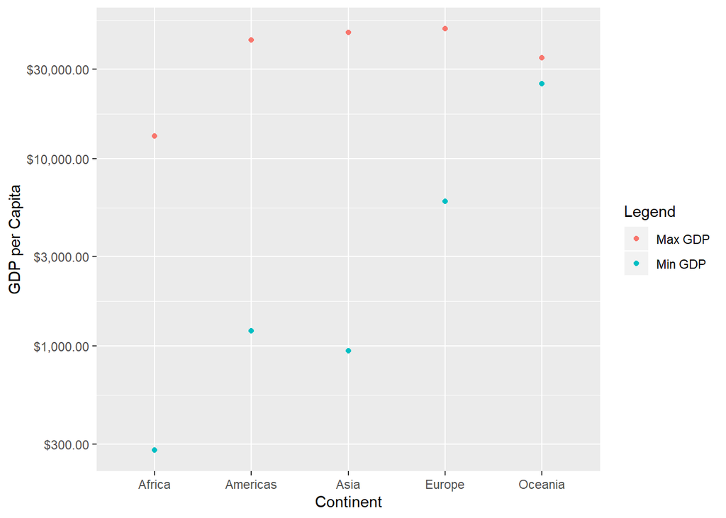

```r
gdpmin_max %>%
  ggplot(aes())+
    geom_point(aes(continent, min_gdp, color = "Min GDP")) +
    geom_point(aes(continent, max_gdp, color = "Max GDP")) +
  labs(x = "Continent", y = "GDP per Capita") +
  scale_y_log10(labels = scales::dollar_format()) +
  scale_color_discrete("Legend")
```

**Task 3.** Below is the spread of GDP per capita within continents. Summary statistics include the minimum, maximum, mean, and median GDP per capita for each continent.

```r
gapminder %>%
  group_by(continent) %>%
  summarize(min_gdp = min(gdpPercap), max_gdp = max(gdpPercap), mean_gdp = mean(gdpPercap), median_gdp = median(gdpPercap), std_gdp = sd(gdpPercap))
```

```
## # A tibble: 5 x 6
##   continent min_gdp max_gdp mean_gdp median_gdp std_gdp
##   <fct>       <dbl>   <dbl>    <dbl>      <dbl>   <dbl>
## 1 Africa       241.  21951.    2194.      1192.   2828.
## 2 Americas    1202.  42952.    7136.      5466.   6397.
## 3 Asia         331  113523.    7902.      2647.  14045.
## 4 Europe       974.  49357.   14469.     12082.   9355.
## 5 Oceania    10040.  34435.   18622.     17983.   6359.
```

Below is a boxplot of GDP per capita for every continent. Asia has the largest spread of GDP per capita, while Oceania has the smallest spread.

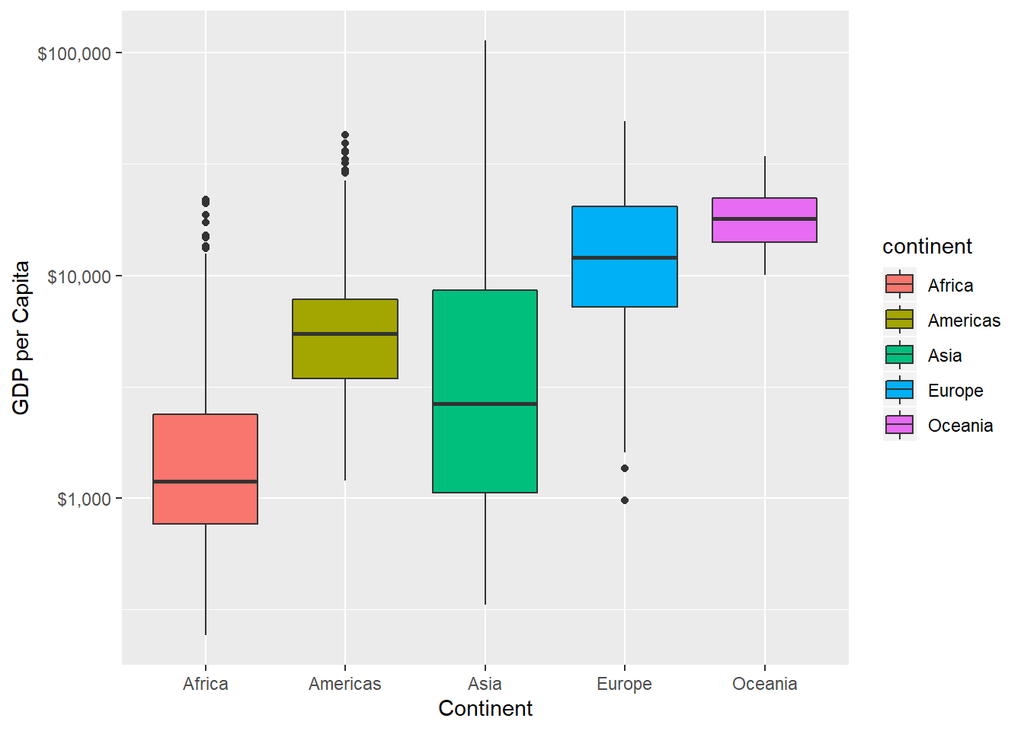

```r
gapminder %>%
  ggplot(aes(continent, gdpPercap, fill = continent)) +
  geom_boxplot() +
  labs(x = "Continent", y = "GDP per Capita") +
  scale_y_log10(labels = scales::dollar_format())
```

**Task 5.** Below is the life expectancy as it changes over time on different continents. I calculated the mean life expectancy across countries within each continent.

```r
life_change <- gapminder %>%
  group_by(continent, year) %>%
  arrange(continent, year) %>%
  summarize(mean_life = mean(lifeExp))
life_change
```

```
## # A tibble: 60 x 3
## # Groups:   continent [5]
##    continent  year mean_life
##    <fct>     <int>     <dbl>
##  1 Africa     1952      39.1
##  2 Africa     1957      41.3
##  3 Africa     1962      43.3
##  4 Africa     1967      45.3
##  5 Africa     1972      47.5
##  6 Africa     1977      49.6
##  7 Africa     1982      51.6
##  8 Africa     1987      53.3
##  9 Africa     1992      53.6
## 10 Africa     1997      53.6
## # ... with 50 more rows
```

Mean life expectancies across all continents have increased over time.

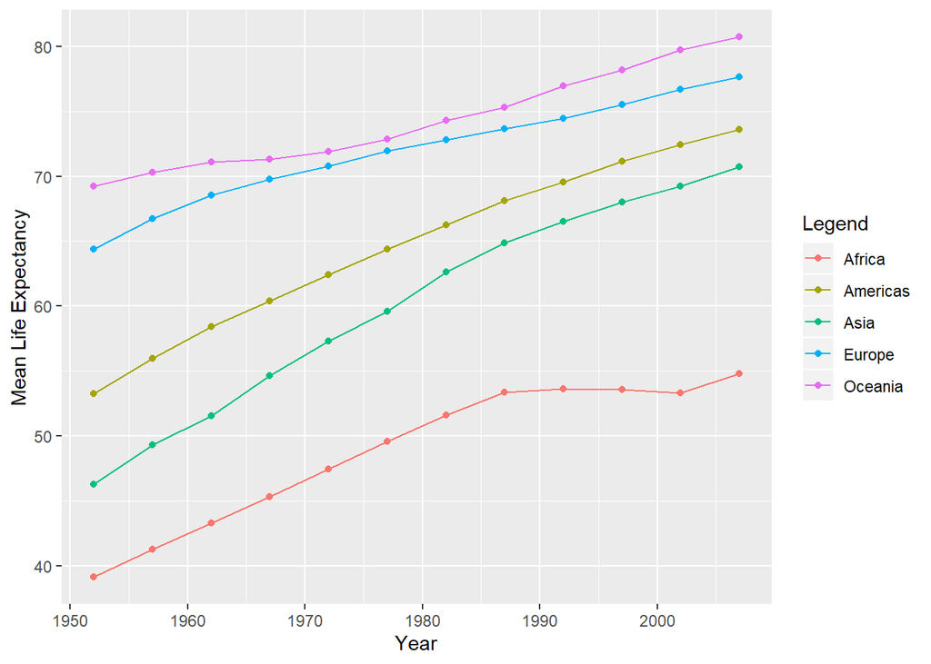

```r
life_change %>%
  ggplot(aes(year, mean_life, group = continent, color = continent)) +
  geom_point() +
  geom_line() +
  labs(x = "Year", y = "Mean Life Expectancy") +
  scale_color_discrete("Legend")
```